# S1 : Marine Ecological Modelling & Global Climate Change

Marine Ecological Modelling  
Global Climate Change

#### S1.1 : Brief recap of R computing basics

author: Jorge Assis  
contact: jmassis@ualg.pt  
code: github.com/jorgeassis  
tweets: twitter.com/jorgemfassis  
journal: [medium.com/theMarineDataScientist](https://medium.com/themarinedatascientist)

##### Starting out in R

R is both a **programming language** and an **interactive environment** for data exploration and statistics and also for computing. The easiest way **to get started** with R is by using the **graphic interface RStudio**. The main way of working with R is the console, where you enter commands and view results. RStudio surrounds this with various conveniences. In addition to the console panel, **RStudio provides** panels containing:

0. **Console panel** for sending R commands
1. **Text editor panel** where R commands can be recorded for future reference;
2. **Environment panel** with a list of variables, which contain values that R has been told to save from previous commands;
3. **File manager panel**;
4. **Help panel** on the functions available in R;
5. **Plots panel**.

[figure not shown]

##### Starting point: Working directory

R is always pointed at a **specific directory on your computer**, the working directory. The command for setting a working directory is **setwd()**. Check out the **help panel**.

```r
# get help on get or set working directory
?getwd
```

##### Load and install packages

There are **more than 10,000 of packages** available to expand R. To see the list of installed packages type **library()**. The same command is used for loading a specific package into the workspace, making it available for the session.

```r
# loads the package raster
library(raster)

# removes package from current workspace
detach(package:raster)
```

If you don’t have a given package, install it with **install.packages()**.

```r
install.packages("raster", dependencies=T)
```

##### Variables and objects

All **data structures and functions are objects** in R.

```r
# list all objects contained in the current workspace
ls()
```

```
## character(0)
```

We can assign data structures and functions to objects using the **assignment operator** (<-). RStudio helpfully shows us the variable in the **Environment pane**.

```r
# assign a sequence to a object named 'mySequence'
mySequence <- seq(1,5)
mySequence
```

```
## [1] 1 2 3 4 5
```

```r
ls()
```

```
## [1] "mySequence"
```

We can remove objects from the workspace using rm().

```r
# removes one object from R environment
rm(mySequence)
mySequence
```

```
## Error in eval(expr, envir, enclos): object 'mySequence' not found
```

```r
ls()
```

```
## character(0)
```

###### Naming objects

There is **no naming convention**. Even in the same package, multiple conventions might be used simultaneously. But usually, it’s advisable to **stay consistent**. Basically, there are five naming conventions to chose from:

1. lowercase (e.g., adjustcolor);
2. period.separated (e.g., plot.new);
3. underscore_separated (e.g., numeric_version);
4. lowerCamelCase (e.g., addTaskCallback)***;
5. UpperCamelCase (e.g., SignatureMethod).

##### Data types and structures

R distinguishes five basic **data types**.

```r
# character
speciesName <- "Laminaria ochroleuca"

# integer (subset of real numbers)
bladeSize <- 41

# numeric (allows decimals)
bladeSize <- 41.4

# factor
demographicTraits <- factor('juvenil',levels=c('spore','juvenil','adult'))
demographicTraits

# boolean
kelpSpecies <- TRUE
kelpSpecies
```

R distinguishes several **objects types** that differ in complexity. **Vectors, matrices and arrays can only contain one data type**. **Data frames can contain different data types in separate columns** but all columns need to have the same length. **Lists can contain different object types and data types**.

```r
# vectors
1:5
5:1
c(1,4,1,8,44,1)
seq(5,10,by=.5)
rev( seq(5,10,by=.5) )
rep(2,10)
rep(c(1,6,5),2)
```

```r
# matrices
myMatrix <- matrix( seq(5,10,length=24) , ncol=4)
myMatrix
```

```
##          [,1]     [,2]     [,3]      [,4]
## [1,] 5.000000 6.304348 7.608696  8.913043
## [2,] 5.217391 6.521739 7.826087  9.130435
## [3,] 5.434783 6.739130 8.043478  9.347826
## [4,] 5.652174 6.956522 8.260870  9.565217
## [5,] 5.869565 7.173913 8.478261  9.782609
## [6,] 6.086957 7.391304 8.695652 10.000000
```

```r
# array (the dim attribute for the array to be created)
myArray <- array(1:24, c(4,3,2) )
myArray
```

```
## , , 1
##
##      [,1] [,2] [,3]
## [1,]    1    5    9
## [2,]    2    6   10
## [3,]    3    7   11
## [4,]    4    8   12
##
## , , 2
##
##      [,1] [,2] [,3]
## [1,]   13   17   21
## [2,]   14   18   22
## [3,]   15   19   23
## [4,]   16   20   24
```

```r
# data frame (with numeric and charcater elements)
courseSchedule <- data.frame(weeks=1:10,
                             funFactor=sample(c('super','ok','pain'),10,replace=T))
courseSchedule
```

```
##    weeks funFactor
## 1      1     super
## 2      2     super
## 3      3        ok
## 4      4      pain
## 5      5        ok
## 6      6      pain
## 7      7     super
## 8      8      pain
## 9      9        ok
## 10    10      pain
```

```r
# lists
memccCourse <- list(course_name="Marine Ecological Modelling and Global Climate Change",
                    module="M1", master_programme="Marine Biology",
                    semester=2, instructors=c('Jorge Assis'),
                    lessons= courseSchedule)
memccCourse
```

```
## $course_name
## [1] "Marine Ecological Modelling and Global Climate Change"
##
## $module
## [1] "M1"
##
## $master_programme
## [1] "Marine Biology"
##
## $semester
## [1] 2
##
## $instructors
## [1] "Jorge Assis"
##
## $lessons
##    weeks funFactor
## 1      1     super
## 2      2     super
## 3      3        ok
## 4      4      pain
## 5      5        ok
## 6      6      pain
## 7      7     super
## 8      8      pain
## 9      9        ok
## 10    10      pain
```

**NA (Not Available) indicates missing values**.

e.g., In a dataset with daily weather measurements over a longer period of time. On one day, the batteries of the weather station were empty and no measurements were taken. **For integrity reasons, empty entries will still be stored** in the data set but will be assigned the missing value ‘NA’.

```r
mean(c(1,5,2,NA,10,4,NA,7))
```

```
## [1] NA
```

```r
mean(c(1,5,2,NA,10,4,NA,7),na.rm=T)
```

```
## [1] 4.833333
```

##### Indexing

**Each element of an object** type is internally assigned an index (positive integer **address**) and you can **retrieve single elements or a subset objects** with these indices.

Square brackets are used for indexing. In data frames (and lists) we can access columns using the ‘$’ operator.

```r
# produce a sequence vector
x <- seq(5,10,by=1)

# retrieve the 3rd element of the vector x
x[3]
```

```
## [1] 7
```

```r
# use address sequences
x[3:4]
```

```
## [1] 7 8
```

```r
# use address vectors
x[c(1,4,6)]
```

```
## [1]  5  8 10
```

```r
# use address negative vector integers
x[-c(1,3:4)]
```

```
## [1]  6  9 10
```

```r
myMatrix
```

```
##          [,1]     [,2]     [,3]      [,4]
## [1,] 5.000000 6.304348 7.608696  8.913043
## [2,] 5.217391 6.521739 7.826087  9.130435
## [3,] 5.434783 6.739130 8.043478  9.347826
## [4,] 5.652174 6.956522 8.260870  9.565217
## [5,] 5.869565 7.173913 8.478261  9.782609
## [6,] 6.086957 7.391304 8.695652 10.000000
```

```r
# retrieve the element in a given matrix position
myMatrix[2,2]
```

```
## [1] 6.521739
```

```r
myArray
```

```
## , , 1
##
##      [,1] [,2] [,3]
## [1,]    1    5    9
## [2,]    2    6   10
## [3,]    3    7   11
## [4,]    4    8   12
##
## , , 2
##
##      [,1] [,2] [,3]
## [1,]   13   17   21
## [2,]   14   18   22
## [3,]   15   19   23
## [4,]   16   20   24
```

```r
# retrieve the element in a given array position
myArray[3,2,2]
```

```
## [1] 19
```

```r
# retrieve the element in a list
memccCourse[1]
```

```
## $course_name
## [1] "Marine Ecological Modelling and Global Climate Change"
```

```r
# retrieve the element in a list
memccCourse['lessons']
```

```
## $lessons
##    weeks funFactor
## 1      1     super
## 2      2     super
## 3      3        ok
## 4      4      pain
## 5      5        ok
## 6      6      pain
## 7      7     super
## 8      8      pain
## 9      9        ok
## 10    10      pain
```

```r
memccCourse$course_name
```

```
## [1] "Marine Ecological Modelling and Global Climate Change"
```

```r
memccCourse$lessons
```

```
##    weeks funFactor
## 1      1     super
## 2      2     super
## 3      3        ok
## 4      4      pain
## 5      5        ok
## 6      6      pain
## 7      7     super
## 8      8      pain
## 9      9        ok
## 10    10      pain
```

```r
# modifying single elements
ecologicalGroups <- c(kelp=5, seagrasses=10, corals=1, fish=20)
ecologicalGroups
```

```
##       kelp seagrasses     corals       fish
##          5         10          1         20
```

```r
ecologicalGroups[1] <- 100
ecologicalGroups
```

```
##       kelp seagrasses     corals       fish
##        100         10          1         20
```

```r
ecologicalGroups["seagrasses"] <- 0
ecologicalGroups
```

```
##       kelp seagrasses     corals       fish
##        100          0          1         20
```

#### S1.2 : Basic programming elements

author: Jorge Assis  
contact: jmassis@ualg.pt  
code: github.com/jorgeassis  
tweets: twitter.com/jorgemfassis  
journal: [medium.com/theMarineDataScientist](https://medium.com/themarinedatascientist)

##### Functions

Functions are the **basic foundations of R**. From opening datasets to produce complex models and plots.

Functions have an **argument list** that can be empty (default expression terms) or have multiple expression terms.

```r
# print character strings
print("Hello world!")
```

```
## [1] "Hello world!"
```

```r
# join character strings
paste("Hello", "world","!")
```

```
## [1] "Hello world !"
```

```r
# join character strings (multiple expression terms)
paste("Hello", "world","!",sep="-")
```

```
## [1] "Hello-world-!"
```

```r
# determine the mean of a vector
myData <- c(2,4,3,2,3,4,2,2)
mean(myData)
```

```
## [1] 2.75
```

```r
# find the arguments, needs and outputs for each function
?mean

# determine the standard deviation of a vector
sd(myData)
```

```
## [1] 0.8864053
```

```r
# random numbers drawn from a given distribution without replacement
sample(1:30,size=5)
```

```
## [1] 28 16 29 13 24
```

```r
# random numbers drawn from a given distribution without replacement
sample(1:10,size=5, replace = FALSE)
```

```
## [1]  8  4  3 10  2
```

###### Writing functions

It is useful to write your own functions to **facilitate recurring computations and improves clarity of scripts**. Functions result in:

1. more **clearly describe and isolate a particular task** in your data analysis workflow.
2. **re-use code**, rather than repeating the same steps several times. This should lead to faster development of scripts and to fewer mistakes. And if there is a mistake it only needs to be fixed in one place.

If the end of a function is reached without **calling return**, the value of the last evaluated expression is returned.

```r
# function without arguments
greetings <- function(){
  print('Hello world')
    }
greetings()
```

```
## [1] "Hello world"
```

```r
# function with one argument
greetings <- function(name){
    print(paste('Hello',name))
    }
greetings('students')
```

```
## [1] "Hello students"
```

```r
greetings('professor')
```

```
## [1] "Hello professor"
```

```r
# function with multiple arguments
myCalc <- function(data1,data2){
  result <- data1 / data2
  return(result)
    }
myCalc(4,2)
```

```
## [1] 2
```

```r
# function with multiple arguments and levels
sumsquare <- function(a, b) {
    intermediateResult <- a + b
    result <- intermediateResult * intermediateResult
    return(result)
}
sumsquare(1,2)
```

```
## [1] 9
```

```r
# functions can be vectorized (each argument can have more than one element)
x <- 1:3
y <- 2
sumsquare(x,y)
```

```
## [1]  9 16 25
```

###### Challenge 1.1

The main objetive of this challenge is to **develop a function** to determine the mean of a numeric vector.

```r
# data and functions needed to accomplish the challenge
myFunction <- function(variables){
    # code goes here
    return( results )
    }
myFunction(variables)

vector <- c(2,3,1,65,3,2)
mean(vector)
```

##### Logic and conditions

**Relational and logical operators** are relevant for data requests or manipulations, and for programming.

| Operator | R meaning |
| --- | --- |
| ! | not |
| & | and |
| \| | or |
| == | equal |
| != | not equal to |
| < | less than |
| <= | less than or equal to |
| > | greater than |
| >= | greater than or equal to |
| %in% | is present |
| ! %in% | is not present |

```r
nameA <- "john"
nameB <- "joseph"
nameA == nameB
```

```
## [1] FALSE
```

```r
nameA != nameB
```

```
## [1] TRUE
```

```r
valueA <- 23
valueB <- 11
valueA >= valueB
```

```
## [1] TRUE
```

```r
myVector <- 1:100
5 %in% myVector
```

```
## [1] TRUE
```

```r
myVector <- c(1,4,3,2,6,5,4,6,7,6,5,22,3)

# finding all occurrences as a logical vector
myVector == 4
```

```
##  [1] FALSE  TRUE FALSE FALSE FALSE FALSE  TRUE FALSE FALSE FALSE FALSE FALSE
## [13] FALSE
```

```r
# returns the first index match
match(4,myVector)
```

```
## [1] 2
```

```r
# returns the index all matchs
which( myVector == 4 )
```

```
## [1] 2 7
```

```r
# TRUE in a logical vector represents '1' in a function
sum(myVector == 4)
```

```
## [1] 2
```

##### Random numbers

It is common to create a vector of random numbers in data analysis, and also to create example data to demonstrate how a procedure works.

```r
#
r <- sample(1:10,5)
r
```

```
## [1]  2  3  8  4 10
```

```r
r <- sample(1:10,5, replace = FALSE)
r
```

```
## [1]  7 10  3  4  8
```

If you run the functions above, you will get different numbers. After all, they are random numbers! Well, **computer generated numbers that are not truly random**, but ‘pseudo-random’. To be able to exactly reproduce examples or data analysis we often want to assure that we take exactly the same ‘random’ sample each time we run our code.

To do that we use **set.seed**. This function initializes the random number generator to a specific point. This is a very important feature, as it allows us to **exactly reproduce results** that involve random sampling.

```r
# random numbers within a given distribution
runif(5, min = 0, max = 1)
```

```
## [1] 0.09259984 0.79363828 0.17367753 0.32958138 0.98237723
```

```r
runif(5, min = 0, max = 1)
```

```
## [1] 0.1741895 0.2405457 0.4329092 0.6978912 0.2694788
```

```r
set.seed(12)
runif(5, min = 0, max = 1)
```

```
## [1] 0.06936092 0.81777520 0.94262173 0.26938188 0.16934812
```

```r
set.seed(12)
runif(5, min = 0, max = 1)
```

```
## [1] 0.06936092 0.81777520 0.94262173 0.26938188 0.16934812
```

##### Control flows

Most programs have two general control-flow features: **alternation and iteration**. Alteration via **if-then-else** branches and iteration is done via **loops**.

##### Alternation

Alternation conditions are **the most important building blocks in programming** because they help structuring the logic of the code. We use conditional expressions if specific computations and actions should only be performed under certain conditions.

R knows three conditional expressions:

1. if(condition){ command block }
2. if(condition){ command block } else { alternative command block }
3. ifelse(condition, command block, alternative command block)

These functions **always require a Boolean condition**, meaning that it needs to evaluate to TRUE or FALSE. Conditional expressions may be nested.

```r
myVector <- c(1,4,3,2,6,5,4,6,7,6,5,22,3)

if( 4 %in% myVector ) { print("The vector contains the element 4") }

if( 42 %in% myVector ) { print("The vector contains the element 42") } else { print("The vector does not contain the element 42") }

ifelse( 4 %in% myVector , "Contains" , "Does not Contain" )

myConditionResult <- ifelse( 4 %in% myVector , 1 , 2 )
myConditionResult + 100
```

###### Challenge 1.2

The main objetive of this challenge is to develop a function using **conditional statments** to check if a given number is positive or negative. The result should be a text displaying “is positive” or “is negative”

```r
# data and functions needed to accomplish the challenge
ifelse(condition, command block, alternative command block)

myFunction <- function(variables){
    # code goes here
    return( results )
    }
myFunction(variables)

print(character)
```

###### Challenge 1.3

The main objetive of this challenge is to develop a function using **more than one argument** with **conditional statments** to check if two given numeric elements are both positive. The result should be “both elements are positive” or “one of the elements is negative”

```r
# data and functions needed to accomplish the challenge
ifelse(condition, command block, alternative command block)

myFunction <- function(variables){
    # code goes here
    return( results )
    }
myFunction(variables)

print(character)
```

##### Iteration

Iteration via loops are **crucial elements in programming**. We use them, for example, for iterating (parts of) programs with different parameters or initial values.

R offers three different loop structures: **repeat**, **while** and **for**, the latter probably being the most commonly used.

The **repeat loop** is the most simplest but maybe also the most dangerous loop structure. If you do not set an appropriate **break**, the loop will iterate forever.

```r
i <- 0
repeat{
  i <- i + 1
  print(i)
  if(i>10) break
  }
```

```
## [1] 1
## [1] 2
## [1] 3
## [1] 4
## [1] 5
## [1] 6
## [1] 7
## [1] 8
## [1] 9
## [1] 10
## [1] 11
```

The control word **next** halts the processing of the current iteration step and advances the looping index.

```r
i <- 0
repeat{
  i <- i+1
  if(i>=3 & i<=8) next
  print(i)
  if (i>=10) break
  }
```

```
## [1] 1
## [1] 2
## [1] 9
## [1] 10
```

The **while loop** is stoped by a condition in the function call. Thus, in the while loop, a command block is iterated until the final condition is fulfilled.

```r
i <- 0
while (i<=10) {
  i <- i + 1
}
```

The **for loop** iterates through all elements of a provided vector: for (i in M).

```r
x <- c(3,6,2,5,10)
for (i in x) {
  print(i^2)
}
```

```
## [1] 9
## [1] 36
## [1] 4
## [1] 25
## [1] 100
```

The **for loop** is ideal to populate data structures.

```r
# populating a vector with the result of a given function (e.g., square / quadratic)
vectorX <- seq(-5,5,length.out = 30)
vectorY <- numeric(0)
vectorY
```

```
## numeric(0)
```

```r
for (i in vectorX) {
  vectorY <- c(vectorY,i^2)
}
vectorY
```

```
##  [1] 25.00000000 21.67063020 18.57907253 15.72532699 13.10939358 10.73127229
##  [7]  8.59096314  6.68846611  5.02378121  3.59690844  2.40784780  1.45659929
## [13]  0.74316290  0.26753864  0.02972652  0.02972652  0.26753864  0.74316290
## [19]  1.45659929  2.40784780  3.59690844  5.02378121  6.68846611  8.59096314
## [25] 10.73127229 13.10939358 15.72532699 18.57907253 21.67063020 25.00000000
```

```r
# now with better indexing (populate with address) and pre-alocated vector
vectorX <- seq(-5,5,length.out = 30)
vectorY <- numeric( length(vectorX) )
vectorY
```

```
##  [1] 0 0 0 0 0 0 0 0 0 0 0 0 0 0 0 0 0 0 0 0 0 0 0 0 0 0 0 0 0 0
```

```r
for (i in 1:length(vectorX) ) {
  vectorY[i] <- vectorX[i]^2
}
vectorY
```

```
##  [1] 25.00000000 21.67063020 18.57907253 15.72532699 13.10939358 10.73127229
##  [7]  8.59096314  6.68846611  5.02378121  3.59690844  2.40784780  1.45659929
## [13]  0.74316290  0.26753864  0.02972652  0.02972652  0.26753864  0.74316290
## [19]  1.45659929  2.40784780  3.59690844  5.02378121  6.68846611  8.59096314
## [25] 10.73127229 13.10939358 15.72532699 18.57907253 21.67063020 25.00000000
```

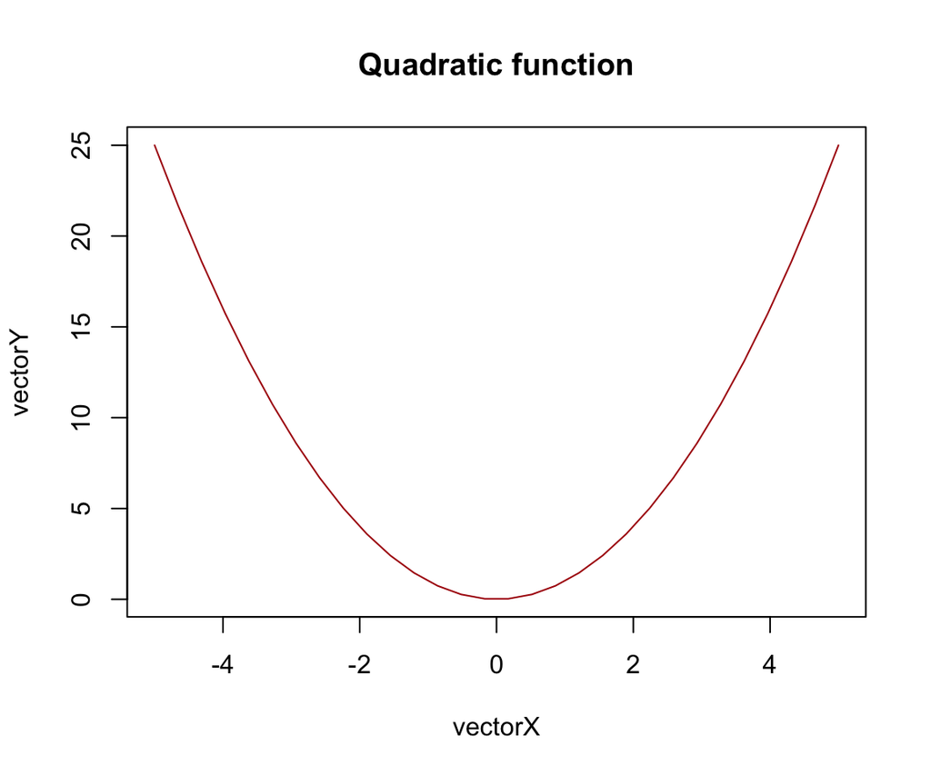

```r
plot(vectorX,vectorY,type="l" , main="Quadratic function" , col="#AC0808")
```

###### Challenge 1.4

The main objetive of this challenge is to **populate a vector** with the number of trials a computer needs to guess a random number (element) given by the user (between 1 and 10000).

```r
# data and functions needed to accomplish the challenge
ifelse(condition, command block, alternative command block)

myFunction <- function(variables){
    # code goes here
    return( results )
    }
myFunction(variables)

repeat{
 # code goes here (break)
}

sample(vector,size)
print(character)
```

##### Data import and export

R offers several options for accessing different data formats. Standard formats include text files, R files (single objects or entire workspaces), and databases. These data can be read in from files using a file path, but also from the Internet using an URL path or from the clipboard.

All objects created in R can be exported to file.

```r
# data frames can be written to file by write.table and its variants
courseSchedule <- data.frame(weeks=1:10,
                             funFactor=sample(c('super','ok','pain'),10,replace=T))

write.table(courseSchedule,"courseSchedule.txt", row.names=F, col.names=T, sep=',')
```

```r
# list all files in your folder
list.files()

# reading data frames
myDF <- read.table('courseSchedule.txt')
myDF <- read.table('courseSchedule.txt', sep=',', header=T)
```

##### Reading and writing R objects and scripts

It is crucial to record the way scripts were performed so we can reproduce them later. The usual workflow is to save your code in an R script (“.R file”).

You can go to “File/New File/R Script” to create a new R script. These files can be sourced in additional scripts to create clean pipelines. To effectively execute R expressions available in the script editor, use the most important keyboard shortcuts: Cmd/Ctrl + Enter.

Objects available in the environment can also be saved (“.RData file”).

```r
# source external file
source("path-to-script.R")

# save objects to external file
myData <- c(1,2,3,4,5)
save(myData,file = "path-to-data.RData")

# save all objects in the environment to external file
save.image(myData,file = "path-to-data.RData")

# load objects from external file
load(file = "path-to-data.RData")
```

###### Commenting the code

Add comments to pipelines, using lines starting with the **# character**. This makes it easier to follow the code.

```r
# my nice comment
myData <- c(32,3,5,4,778,4,3,5,7,4)

# my nice comment
mean(myData)

# my nice comment
myData <- myData[myData < quantile(myData,0.95)]

# my nice comment
mean(myData)
```

###### Snippets

Snippet is a programming term for a **small region of re-usable source code**, machine code, or text. Ordinarily, these are formally defined operative units to incorporate into larger programming modules.

##### References

Global change impacts on biodiversity. Available at: https://damariszurell.github.io/HU-GCIB

Monash Bioinformatics Platform. Available at: https://monashdatafluency.github.io/r-intro-2/

Hijmans, R.J. (2020) Spatial Data Science with R. Available at: https://rspatial.org/raster/index.html

R Markdown tutorial developed by Jorge Assis under the International License [[CC BY 4.0]](https://creativecommons.org/licenses/by/4.0/). When using, copying or modifying, the attribution citation should be **Assis, J. (2020) Marine Ecological Modelling and Global Climate Change. theMarineDatasSientist**.